# Replicating the SHAP Need-Axis from Source

# 2 The two sets of SHAP weights

This table is the conceptual spine of the whole note, so it is worth reading slowly. There are two distinct objects. The **raw SHAP** (right column) is what the model actually produces: for every country, every year, and every feature, a *signed* number saying how much that capability pushed that country’s predicted competitiveness up or down. The **shipped `shap_mean_z`** (left column) is what the Atlas radar is built from — and it is *not* the raw SHAP, it is the raw SHAP after three deliberate reductions: take the absolute value (drop the sign), z-score within each year and average (drop the magnitude), and average over all country-years (drop the country dimension). Each row below is one of those reductions. The argument of this note is simply that all three discard information a “what to build” reading needs.

|  | **Shipped `shap_mean_z`** (the radar axis) | **Raw SHAP** (what we regenerated) |
| --- | --- | --- |
| Granularity | one number per feature | one signed value per **country × year × feature** |
| Sign | absolute-valued — **unsigned** | **signed** (+ toward competitive / − away) |
| Magnitude | z-scored per year → magnitude divided out | raw contribution retained |
| Country dimension | averaged over all country-years | **preserved** |
| Selection | thresholded at `mean\|z\| ≥ 0.5` | (same features, for comparability) |

Three things are stripped between the two columns — **sign, magnitude, and the country dimension.** The rest of this note quantifies each.

# 3 EDA 1 — the two importances decouple

If the z-scored axis tracked genuine magnitude, the shipped `mean|z|` and the raw `mean|SHAP|` would rank features similarly. They do not.

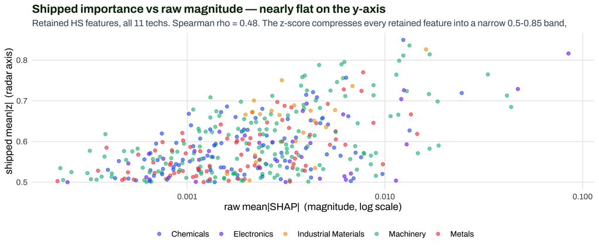

```r
cor_hs <- kept |> filter(category %in% CATS)
rr <- round(cor(cor_hs$mean_abs_z, cor_hs$raw_mean_abs_shap, method="spearman"), 2)
ggplot(cor_hs, aes(raw_mean_abs_shap, mean_abs_z, colour = category)) +
  geom_point(alpha = .6, size = 1.6) +
  scale_x_log10() + scale_colour_manual(values = CAT_COL, name = NULL) +
  labs(x = "raw mean|SHAP|  (magnitude, log scale)", y = "shipped mean|z|  (radar axis)",
       title = "Shipped importance vs raw magnitude — nearly flat on the y-axis",
       subtitle = paste0("Retained HS features, all 11 techs. Spearman rho = ", rr,
                         ". The z-score compresses every retained feature into a narrow 0.5-0.85 band,")) +
  theme(legend.position = "bottom")
```

The shipped axis lives in a compressed **0.5–0.85** band regardless of raw magnitude — the Cohen’s-*d* cut plus z-scoring flatten features that differ by an order of magnitude in raw contribution onto nearly the same value. So when clusters are formed by **summing** these near-equal values, the cluster totals track **feature counts**, not importance.

# 4 EDA 2 — the “most needed” cluster flips for 9 of 11 techs

Because the shipped axis sums near-equal values, the biggest cluster wins; because raw magnitude varies, a different cluster often wins once magnitude is preserved.

```r
topcl <- catt |> group_by(tech) |>
  summarise(`Shipped top (sum of z)` = category[which.max(pct_shipped_sum_z)],
            `Magnitude top (raw mean)` = category[which.max(pct_raw_mean)], .groups="drop") |>
  mutate(Flip = ifelse(`Shipped top (sum of z)`!=`Magnitude top (raw mean)`, "⚠ flips",""),
         tech = factor(tech, TECHS)) |> arrange(tech)
nfl <- sum(topcl$Flip=="⚠ flips")
kable(topcl, caption = sprintf("Top 'need' cluster under the shipped sum-of-z axis vs a magnitude-preserving raw mean|SHAP|. The top priority flips for %d of 11 technologies. The shipped axis makes Machinery the top cluster for 8 of 11 (it holds the most product codes); magnitude spreads the winners across Electronics, Chemicals, Metals, and Industrial Materials.", nfl))
```

Top ‘need’ cluster under the shipped sum-of-z axis vs a magnitude-preserving raw mean|SHAP|. The top priority flips for 9 of 11 technologies. The shipped axis makes Machinery the top cluster for 8 of 11 (it holds the most product codes); magnitude spreads the winners across Electronics, Chemicals, Metals, and Industrial Materials.

| tech | Shipped top (sum of z) | Magnitude top (raw mean) | Flip |
| --- | --- | --- | --- |
| Solar | Chemicals | Electronics | ⚠ flips |
| Wind | Machinery | Chemicals | ⚠ flips |
| Batteries | Machinery | Electronics | ⚠ flips |
| EVs | Machinery | Industrial Materials | ⚠ flips |
| Nuclear | Metals | Chemicals | ⚠ flips |
| Geothermal | Machinery | Machinery |  |
| Heat Pumps | Machinery | Machinery |  |
| Electrolyzers | Machinery | Metals | ⚠ flips |
| Transmission | Machinery | Electronics | ⚠ flips |
| Magnets | Metals | Chemicals | ⚠ flips |
| Biofuel | Machinery | Chemicals | ⚠ flips |

[figure not shown]

```r
hd <- catt |> select(tech, category, pct_shipped_sum_z, pct_raw_mean) |>
  pivot_longer(c(pct_shipped_sum_z, pct_raw_mean), names_to="axis", values_to="pct") |>
  mutate(axis = recode(axis, pct_shipped_sum_z="Shipped (sum of z)", pct_raw_mean="Magnitude (raw mean)"),
         tech = factor(tech, rev(TECHS)), category = factor(category, CATS))
ggplot(hd, aes(category, tech, fill = pct)) +
  geom_tile(colour="white", linewidth=.6) +
  geom_text(aes(label = ifelse(is.na(pct)|pct<1,"",sprintf("%.0f",pct))), family="Archivo", size=2.7, colour="#0b1a12") +
  facet_wrap(~axis) +
  scale_fill_gradient(low="#f0f7f0", high=NZ_GREEN, na.value="grey93", name="% of need") +
  labs(x=NULL, y=NULL, title="Cluster need under the two aggregations",
       subtitle="Left: shipped sum-of-z lights up the Machinery column (count-driven). Right: raw magnitude redistributes.") +
  theme(axis.text.x = element_text(angle=20, hjust=1), legend.position="bottom")
```

# 5 EDA 3 — which weights are negative? (the sign the axis discards)

The shipped axis is `|SHAP|`, so it cannot tell whether a capability pushes a country *toward* or *away* from predicted competitiveness. The raw SHAP is signed, so we can ask directly.

```r
neg <- kept |> summarise(
  `retained features` = n(),
  `net-negative (mean SHAP < 0)` = sum(mean_shap_signed < 0),
  `% net-negative` = round(mean(mean_shap_signed < 0)*100, 1),
  `median % of country-years negative` = round(median(pct_negative), 1))
kable(neg, caption = "Sign of the retained features. Nearly half carry a net-negative mean SHAP, and the median retained feature is negative in ~73% of country-years — all invisible under |SHAP|.")
```

Sign of the retained features. Nearly half carry a net-negative mean SHAP, and the median retained feature is negative in ~73% of country-years — all invisible under |SHAP|.

| retained features | net-negative (mean SHAP < 0) | % net-negative | median % of country-years negative |
| --- | --- | --- | --- |
| 448 | 209 | 46.7 | 73.3 |

This small table is the headline of the section: of the features the radar keeps, it counts how many have a *net-negative* average SHAP, and for the typical feature, in what share of country-years its contribution is negative. Both numbers are large — and both are erased by the `|SHAP|` step before anyone sees the radar.

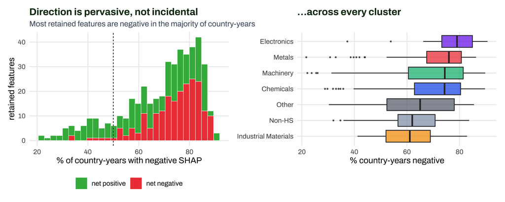

```r
p1 <- ggplot(kept, aes(pct_negative, fill = mean_shap_signed < 0)) +
  geom_histogram(bins = 30, colour="white", linewidth=.2) +
  geom_vline(xintercept = 50, linetype="22", colour="#334155") +
  scale_fill_manual(values = c(`TRUE`="#ef4444", `FALSE`="#3cb54a"),
                    labels = c("net positive","net negative"), name=NULL) +
  labs(x="% of country-years with negative SHAP", y="retained features",
       title="Direction is pervasive, not incidental",
       subtitle="Most retained features are negative in the majority of country-years") +
  theme(legend.position = "bottom")
p2 <- ggplot(kept, aes(x = fct_reorder(category, pct_negative), y = pct_negative, fill = category)) +
  geom_boxplot(alpha=.75, outlier.size=.6) + coord_flip() +
  scale_fill_manual(values = CAT_COL, guide="none") +
  labs(x=NULL, y="% country-years negative", title="…across every cluster", subtitle=" ")
p1 | p2
```

**Reading the panels.** In the left panel each retained feature contributes one observation; the horizontal axis is the share of its country-years in which its SHAP is negative — i.e. in which having that capability was associated with *lower* predicted competitiveness — and the dashed line marks 50%. Most of the mass sits to the *right* of that line, meaning most features are negative more often than not; the bar colour flags whether the feature’s overall average is net-negative. The right panel breaks the same quantity out by cluster, showing the negativity is spread across all five capability groups rather than hiding in one. The takeaway is that direction is not a fringe phenomenon in a few odd features — it is the normal state of most of the axis.

```r
kept |> arrange(mean_shap_signed) |> slice_head(n = 10) |>
  transmute(Tech = tech, Feature = feature, Cluster = category,
            `Mean SHAP (signed)` = round(mean_shap_signed, 4),
            `% country-yrs negative` = round(pct_negative, 0),
            `Shipped mean|z|` = round(mean_abs_z, 2)) |>
  kable(caption = "The ten most net-negative retained features. Each ships as a positive-magnitude 'need'; the sign that says the model reads them as pushing AWAY from competitiveness (on net) is discarded.")
```

The ten most net-negative retained features. Each ships as a positive-magnitude ‘need’; the sign that says the model reads them as pushing AWAY from competitiveness (on net) is discarded.

| Tech | Feature | Cluster | Mean SHAP (signed) | % country-yrs negative | Shipped mean\|z\| |
| --- | --- | --- | --- | --- | --- |
| Transmission | t_854690 | Electronics | -0.0031 | 71 | 0.73 |
| Biofuel | nb_940390 | Machinery | -0.0023 | 64 | 0.80 |
| Biofuel | nb_844190 | Machinery | -0.0022 | 63 | 0.79 |
| Biofuel | b_381590 | Chemicals | -0.0021 | 55 | 0.85 |
| Biofuel | b_150790 | Other | -0.0018 | 78 | 0.60 |
| Biofuel | b_281121 | Chemicals | -0.0016 | 74 | 0.72 |
| Transmission | t_850490 | Electronics | -0.0016 | 71 | 0.82 |
| Geothermal | ng_340319 | Chemicals | -0.0013 | 82 | 0.59 |
| Electrolyzers | ne_390710 | Chemicals | -0.0012 | 72 | 0.71 |
| Nuclear | n_284410 | Chemicals | -0.0011 | 88 | 0.51 |

Each row here is a concrete example of the reversal: a feature whose *average* signed contribution is among the most negative of all — the model, on net, reads it as pulling countries *away* from competitiveness — yet it enters the radar as a positive-magnitude “need,” because `|SHAP|` keeps only the size of the contribution and drops the minus sign. The last column shows the magnitude these features carry onto the radar despite their negative direction.

# 6 EDA 4 — the mean collapses country-year variation

Each `mean|SHAP|` (and hence `mean|z|`) averages over ~3,199 country-years. How much variation does that single number hide?

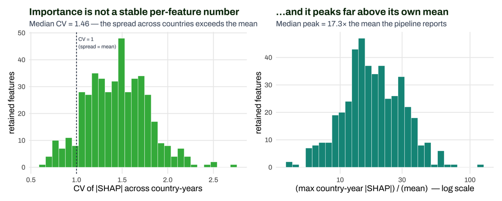

```r
s <- disp |> summarise(`median CV` = round(median(cv),2),
                       `median max/mean` = round(median(max_over_mean),1),
                       `median top-2% share` = round(median(top2pct_share)*100,0),
                       `median % below ½ mean` = round(median(frac_below_half_mean)*100,0))
p1 <- ggplot(disp, aes(cv)) + geom_histogram(bins=30, fill=NZ_GREEN, colour="white", linewidth=.2) +
  geom_vline(xintercept=1, linetype="22", colour="#334155") +
  annotate("text", x=1.02, y=Inf, vjust=1.5, hjust=0, label="CV = 1\n(spread = mean)", family="Archivo", size=2.6, colour="#334155") +
  labs(x="CV of |SHAP| across country-years", y="retained features",
       title="Importance is not a stable per-feature number",
       subtitle=paste0("Median CV = ", s$`median CV`, " — the spread across countries exceeds the mean"))
p2 <- ggplot(disp, aes(max_over_mean)) + geom_histogram(bins=30, fill="#0d9488", colour="white", linewidth=.2) +
  scale_x_log10() +
  labs(x="(max country-year |SHAP|) / (mean)  — log scale", y="retained features",
       title="…and it peaks far above its own mean",
       subtitle=paste0("Median peak = ", s$`median max/mean`, "× the mean the pipeline reports"))
p1 | p2
```

**Reading the two histograms.** Each retained feature contributes one observation to each panel. On the left is the coefficient of variation (CV) of a feature’s `|SHAP|` across all its country-years — its spread divided by its own mean. A CV above 1 (dashed line) means the feature varies *more* across countries than its average value is large, and the bulk of features sit there. On the right is how many times bigger the single most-important country-year is than the mean the pipeline reports; a median of roughly 17× says the reported number badly *understates* the feature’s importance for the country where it matters most. Both panels make the same point from two angles: the one averaged number the pipeline keeps is not a stable property of the feature — it is a smear over wildly unequal country-years.

```r
kable(s, caption = "The single mean|SHAP| collapses a heavy-tailed country-year distribution: spread larger than the center (CV~1.5), a peak ~17x the mean, ~17% of the mass in the top 2% of country-years, and ~40% of country-years below half the mean.")
```

The single mean|SHAP| collapses a heavy-tailed country-year distribution: spread larger than the center (CV~1.5), a peak ~17x the mean, ~17% of the mass in the top 2% of country-years, and ~40% of country-years below half the mean.

| median CV | median max/mean | median top-2% share | median % below ½ mean |
| --- | --- | --- | --- |
| 1.46 | 17.3 | 17 | 41 |

The distribution is heavy-tailed and country-specific. Concretely, for the top retained features of three technologies, the per-country-year `|SHAP|` fans out across two orders of magnitude while the pipeline reports only the diamond:

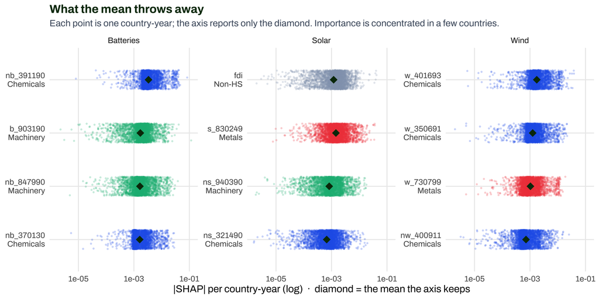

```r
exd <- ex |> mutate(lab = paste0(str_trunc(feature, 12), "\n", category))
ggplot(exd, aes(x = reorder(lab, abs_shap, FUN=median), y = abs_shap + 1e-6)) +
  geom_jitter(aes(colour = category), width=.18, alpha=.18, size=.5) +
  stat_summary(fun = mean, geom = "point", shape=18, size=4, colour = NZ_DARK) +
  scale_y_log10() + coord_flip() +
  scale_colour_manual(values = CAT_COL, guide="none") +
  facet_wrap(~tech, scales="free_y") +
  labs(x=NULL, y="|SHAP| per country-year (log)  ·  diamond = the mean the axis keeps",
       title="What the mean throws away",
       subtitle="Each point is one country-year; the axis reports only the diamond. Importance is concentrated in a few countries.")
```

**Implication.** The radar’s “need” is a **portfolio average that fits almost no individual country** — it over-credits the ~40% of countries for which a feature is near-inert and under-credits ~17× the country for which it is decisive. Since a country’s gap analysis is inherently about *that* country, the need axis would be far more informative computed **per country from its own SHAP row** than from the pooled mean. (The concentration itself is expected — `RCA>1` is rare so the model leans on the few threshold countries — which is the point: the country dimension carries the signal, and averaging discards it.)

# 7 EDA 5 — count-driven, confirmed from source

Closing the loop on the audit’s central claim, now on regenerated data: the shipped cluster axis is almost perfectly the product count.

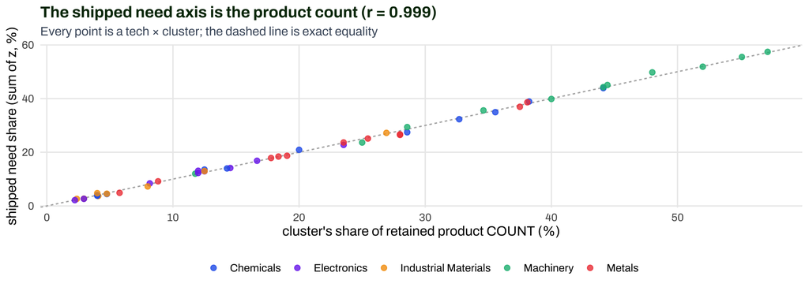

```r
cc <- catt |> group_by(tech) |>
  mutate(count_share = n_features/sum(n_features, na.rm=TRUE)*100) |> ungroup() |>
  filter(!is.na(pct_shipped_sum_z))
rc <- round(cor(cc$pct_shipped_sum_z, cc$count_share), 3)
ggplot(cc, aes(count_share, pct_shipped_sum_z, colour = category)) +
  geom_abline(slope=1, intercept=0, linetype="22", colour="grey70") +
  geom_point(alpha=.8, size=2) +
  scale_colour_manual(values = CAT_COL, name=NULL) +
  labs(x="cluster's share of retained product COUNT (%)", y="shipped need share (sum of z, %)",
       title=paste0("The shipped need axis is the product count (r = ", rc, ")"),
       subtitle="Every point is a tech × cluster; the dashed line is exact equality") +
  theme(legend.position="bottom")
```

**Reading the plot.** Each point is one technology × cluster. The horizontal axis is that cluster’s share of the retained product *count* — literally the fraction of the technology’s kept HS codes that fall in it — and the vertical axis is its share of the shipped “need.” The dashed line is exact equality. The points sit almost on it (r = 0.999), which means the need a cluster is assigned is nearly a deterministic function of how many products it contains. This is the mechanical endpoint of EDA 1: once the year-z-score flattens every retained feature to nearly the same value, summing those values within a cluster is arithmetically almost the same as *counting* them. **Implication:** the shipped axis is, to a very good approximation, answering “which cluster holds the most HS codes” — a question about the composition of the green dictionary, not about which capability a technology most needs. That gap between the two questions is the entire reason this note exists.

# 8 Assessment — how the two weight sets differ

The reproduction settles the factual questions and sharpens the audit:

1. **Selection is faithful; magnitudes are vintage-sensitive.** The retained feature *set* reproduces 1:1 for all 11 techs (Solar bit-exact), so the model and its Cohen’s-*d* selection are exactly as documented. Only the precise z-scored magnitudes drift on the ten techs whose trade inputs were refreshed after shipping — a reason to rebuild `pc_features` from the current inputs, not a method flaw.
2. **The shipped axis and a magnitude axis disagree about priorities.** Shipped `mean|z|` decouples from raw `mean|SHAP|` (low rank correlation), so the sum-by-cluster axis tracks **product counts** (r ≈ 0.999) and the **top-priority cluster flips for 9 of 11 technologies** once magnitude is preserved. The shipped axis systematically favours **Machinery**, the largest-count cluster.
3. **Sign is discarded.** ~47% of retained features carry a **net-negative** mean SHAP (median feature negative in ~73% of country-years). The `|SHAP|` step erases whether a capability, for a given country, is associated with closing the competitiveness gap — first-order information for a “what to build” reading.
4. **Country-year variation is collapsed.** The mean hides a heavy-tailed, country-specific distribution (CV ≈ 1.5; peak ≈ 17× the mean; ~40% of country-years below half the mean). The country-invariant “standard profile” fits few actual countries.

**Bottom line.** The shipped `shap_mean_z` is a faithful *feature-selection* summary — but as a *quantitative, country-facing need axis* it has been stripped of the three things that reading needs: **magnitude** (→ it counts products), **sign** (→ it can’t say help vs. hurt), and the **country dimension** (→ it fits no one country). All three are recoverable from the raw signed SHAP regenerated here (`analysis/ml/raw_signed/`), which is exactly what a magnitude-preserving, signed, per-country need axis would be built from.

**Constructive follow-on → `target_profile.qmd`.** This note is diagnostic; the companion `target_profile.qmd` builds the fix. It shows (a) a **common “standard profile” is defensible** — countries rank-agree on the *shape* of each tech’s needs (median ρ ≈ 0.89), so EDA 4’s dispersion is a *scale* fact for the gap layer, not a refutation of the target; and (b) the **negative signs above are a base-rate artifact, not “avoid”** — split by the RCA>1 class, *zero* of the retained radar features point away among competitive producers. It then rebuilds the axis from the winners’ signed SHAP (magnitude- and direction-preserving), which moves the top-priority cluster for 5 of 11 techs.

# 9 Reproducibility

`scripts/ml/regen_shap.py --tech <Tech>` regenerates every artifact under `analysis/ml/` from the CICE clone (`~/Documents/R/CICE`); `requirements.txt` pins the environment. The per-tech config (input file, target `dv_*`, `excluded_cols`, pinned `n_estimators`/`max_depth`) is transcribed verbatim from the notebooks; seed `28` is used throughout. Re-run against a refreshed clone to update the fidelity check.